# Vignette

Jacqueline R.M.A. Maasch

# `sanzo`: Color Palettes Based on the Works of Sanzo Wada

An R package by JRMA Maasch (2019).

This vignette is intended to share function documentation and code for several different use cases for this package. Find more information about this package at https://github.com/jmaasch/sanzo.

## Load packages

```r
# Install package if needed.
# devtools::install_github("jmaasch/sanzo")

# Load sanzo.
library(sanzo)

# Load packages for ggplot2 demos.
library(ggplot2)
library(ggthemes)
```

## Functions.

- `sanzo.duo(palette_name)` : return duo palette
- `sanzo.trio(palette_name)` : return trio palette
- `sanzo.quad(palette_name)` : return quad palette
- `sanzo.demo2()` : print demo plots for all duo palettes
- `sanzo.demo3()` : print demo plots for all trio palettes
- `sanzo.demo4()` : print demo plots for all quad palettes
- `sanzo.demo.all()` : print demo plots for all palettes
- `sanzo.info2()` : return data frame of hexadecimals and urls for all duo palettes
- `sanzo.info3()` : return data frame of hexadecimals and urls for all trio palettes
- `sanzo.info4()` : return data frame of hexadecimals and urls for all quad palettes
- `sanzo.info.all()` : return data frame of hexadecimals and urls for all palettes

## View function documentation.

Precede any function by a question mark to access description, arguments, return value, and usage suggestions.

```r
# Examples:
?sanzo.info2()
?sanzo.trio()
```

## View metadata for all duos, trios, and quads.

To quickly access palette names:

```r
names(duos)
```

```
##  [1] "c006" "c007" "c008" "c033" "c035" "c047" "c070" "c071" "c074" "c079"
## [11] "c085" "c091" "c095" "c102" "c103" "c106" "c114" "c118" "c119" "c229"
```

```r
names(trios)
```

```
##  [1] "c121" "c139" "c142" "c148" "c149" "c157" "c163" "c171" "c172" "c174"
## [11] "c194" "c204" "c205" "c207" "c223" "c226" "c232" "c239" "c240" "c343"
```

```r
names(quads)
```

```
##  [1] "c249" "c252" "c263" "c268" "c271" "c273" "c279" "c283" "c289" "c293"
## [11] "c296" "c302" "c310" "c321" "c329" "c330" "c332" "c339" "c341" "c348"
```

The following functions return a data frame containing long-form names, short-form IDs, hexadecimal values, and links to Dain M. Blodorn Kim’s https://sanzo-wada.dmbk.io for further palette information.

```r
knitr::kable(sanzo.info2())
```

| DUO PALETTE | ID | HEX VALUES | URL |
| --- | --- | --- | --- |
| Combination 6 | c006 | #ff616b, #000831 | https://sanzo-wada.dmbk.io/combination/6 |
| Combination 7 | c007 | #ff5200, #b3e8c2 | https://sanzo-wada.dmbk.io/combination/7 |
| Combination 8 | c008 | #c2612c, #b8b8ff | https://sanzo-wada.dmbk.io/combination/8 |
| Combination 33 | c033 | #b85e00, #1b3644 | https://sanzo-wada.dmbk.io/combination/33 |
| Combination 35 | c035 | #b08699, #a10b2b | https://sanzo-wada.dmbk.io/combination/35 |
| Combination 47 | c047 | #c9303e, #bfabcc | https://sanzo-wada.dmbk.io/combination/47 |
| Combination 70 | c070 | #b85e00, #405416 | https://sanzo-wada.dmbk.io/combination/70 |
| Combination 71 | c071 | #a90636, #d99e73 | https://sanzo-wada.dmbk.io/combination/71 |
| Combination 74 | c074 | #b5ffc2, #2dbc94 | https://sanzo-wada.dmbk.io/combination/74 |
| Combination 79 | c079 | #651300, #2dbc94 | https://sanzo-wada.dmbk.io/combination/79 |
| Combination 85 | c085 | #c74300, #008aa1 | https://sanzo-wada.dmbk.io/combination/85 |
| Combination 91 | c091 | #5c2c45, #c05200 | https://sanzo-wada.dmbk.io/combination/91 |
| Combination 95 | c095 | #681916, #06004f | https://sanzo-wada.dmbk.io/combination/95 |
| Combination 102 | c102 | #ebd999, #c05200 | https://sanzo-wada.dmbk.io/combination/102 |
| Combination 103 | c103 | #c2612c, #2d0060 | https://sanzo-wada.dmbk.io/combination/103 |
| Combination 106 | c106 | #008aa1, #06004f | https://sanzo-wada.dmbk.io/combination/106 |
| Combination 114 | c114 | #ffab00, #008aa1 | https://sanzo-wada.dmbk.io/combination/114 |
| Combination 118 | c118 | #e0b81f, #362304 | https://sanzo-wada.dmbk.io/combination/118 |
| Combination 119 | c119 | #a6e6db, #0d2b52 | https://sanzo-wada.dmbk.io/combination/119 |
| Combination 229 | c229 | #172713, #b5d1cc | https://sanzo-wada.dmbk.io/combination/229 |

```r
knitr::kable(sanzo.info3())
```

| TRIO PALETTE | ID | HEX VALUES | URL |
| --- | --- | --- | --- |
| Combination 121 | c121 | #6c2b11, #d99e73, #405416 | https://sanzo-wada.dmbk.io/combination/121 |
| Combination 139 | c139 | #96bfe6, #000831, #b5d1cc | https://sanzo-wada.dmbk.io/combination/139 |
| Combination 142 | c142 | #9e194d, #baa600, #96bfe6 | https://sanzo-wada.dmbk.io/combination/142 |
| Combination 148 | c148 | #d1bd19, #ffab00, #29bdad | https://sanzo-wada.dmbk.io/combination/148 |
| Combination 149 | c149 | #d1bd19, #ff5200, #0f261f | https://sanzo-wada.dmbk.io/combination/149 |
| Combination 157 | c157 | #6f0043, #d1bd19, #4f8fe6 | https://sanzo-wada.dmbk.io/combination/157 |
| Combination 163 | c163 | #ffe600, #b5ffc2, #008aa1 | https://sanzo-wada.dmbk.io/combination/163 |
| Combination 171 | c171 | #730f1f, #ff8c00, #b3e8c2 | https://sanzo-wada.dmbk.io/combination/171 |
| Combination 172 | c172 | #c2612c, #008aa1, #3400a3 | https://sanzo-wada.dmbk.io/combination/172 |
| Combination 174 | c174 | #ffa6d9, #bfabcc, #6b2e63 | https://sanzo-wada.dmbk.io/combination/174 |
| Combination 194 | c194 | #fa2b00, #ffcfc4, #4f8fe6 | https://sanzo-wada.dmbk.io/combination/194 |
| Combination 204 | c204 | #b319ab, #c2612c, #a6e6db | https://sanzo-wada.dmbk.io/combination/204 |
| Combination 205 | c205 | #730f1f, #f59994, #2619d1 | https://sanzo-wada.dmbk.io/combination/205 |
| Combination 207 | c207 | #9b5348, #b3e8c2, #000000 | https://sanzo-wada.dmbk.io/combination/207 |
| Combination 223 | c223 | #b08699, #d99e73, #b5ffc2 | https://sanzo-wada.dmbk.io/combination/223 |
| Combination 226 | c226 | #5c2c45, #ffb852, #2619d1 | https://sanzo-wada.dmbk.io/combination/226 |
| Combination 232 | c232 | #d60036, #f2ad78, #000831 | https://sanzo-wada.dmbk.io/combination/232 |
| Combination 239 | c239 | #b08699, #c4bf33, #b3e8c2 | https://sanzo-wada.dmbk.io/combination/239 |
| Combination 240 | c240 | #ff788c, #ffff00, #29bdad | https://sanzo-wada.dmbk.io/combination/240 |
| Combination 343 | c343 | #a93400, #ebd999, #505423 | https://sanzo-wada.dmbk.io/combination/343 |

```r
knitr::kable(sanzo.info4())
```

| QUAD PALETTE | ID | HEX VALUES | URL |
| --- | --- | --- | --- |
| Combination 249 | c249 | #681916, #c0b490, #d1bd19, #417777 | https://sanzo-wada.dmbk.io/combination/249 |
| Combination 252 | c252 | #e62e73, #b85e00, #baa600, #2dbc94 | https://sanzo-wada.dmbk.io/combination/252 |
| Combination 263 | c263 | #a93400, #f2ad78, #b5ffc2, #1b3644 | https://sanzo-wada.dmbk.io/combination/263 |
| Combination 268 | c268 | #b08699, #b85e00, #172713, #bfffe6 | https://sanzo-wada.dmbk.io/combination/268 |
| Combination 271 | c271 | #b90078, #94ff94, #2dbc94, #0f261f | https://sanzo-wada.dmbk.io/combination/271 |
| Combination 273 | c273 | #ffb3f0, #6f0043, #9b5348, #b5d1cc | https://sanzo-wada.dmbk.io/combination/273 |
| Combination 279 | c279 | #b85e00, #f59994, #c0b490, #0d2b52 | https://sanzo-wada.dmbk.io/combination/279 |
| Combination 283 | c283 | #a7374b, #730f1f, #85b857, #6bffb3 | https://sanzo-wada.dmbk.io/combination/283 |
| Combination 289 | c289 | #f2ff26, #bdf226, #202d85, #06004f | https://sanzo-wada.dmbk.io/combination/289 |
| Combination 293 | c293 | #b85e00, #b5ffc2, #65a98f, #40c945 | https://sanzo-wada.dmbk.io/combination/293 |
| Combination 296 | c296 | #f5f5b8, #d99e73, #5e4017, #1b3644 | https://sanzo-wada.dmbk.io/combination/296 |
| Combination 302 | c302 | #ffb852, #c0b490, #bfffe6, #008aa1 | https://sanzo-wada.dmbk.io/combination/302 |
| Combination 310 | c310 | #f5f5b8, #f2ad78, #718600, #172713 | https://sanzo-wada.dmbk.io/combination/310 |
| Combination 321 | c321 | #b08699, #f5f5b8, #172713, #96bfe6 | https://sanzo-wada.dmbk.io/combination/321 |
| Combination 329 | c329 | #ffb852, #bfabcc, #340059, #1b3644 | https://sanzo-wada.dmbk.io/combination/329 |
| Combination 330 | c330 | #bcd382, #bfffe6, #96bfe6, #2dbc94 | https://sanzo-wada.dmbk.io/combination/330 |
| Combination 332 | c332 | #ff7399, #d50c42, #172713, #00592e | https://sanzo-wada.dmbk.io/combination/332 |
| Combination 339 | c339 | #d99e73, #de4500, #a6e6db, #202d85 | https://sanzo-wada.dmbk.io/combination/339 |
| Combination 341 | c341 | #ff616b, #328e13, #172713, #a6e6db | https://sanzo-wada.dmbk.io/combination/341 |
| Combination 348 | c348 | #bcd382, #328e13, #172713, #340059 | https://sanzo-wada.dmbk.io/combination/348 |

## View palette demos.

To illustrate their potential, each color combination can be demo’d via base R scatter and bar plots. The output of `sanzo.demo2()`, `sanzo.demo3()`, `sanzo.demo4()`, and `sanzo.demo.all()` can be previewed at https://github.com/jmaasch/sanzo.

## Use with base R.

These examples use data from the `datasets` package and should be replicable.

### Scatter plot.

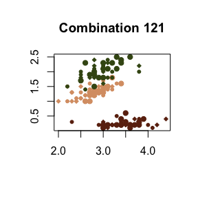

```r
plot(iris$Sepal.Width, iris$Petal.Width, pch = 18:20, main = "Combination 121",
     ylab = "", xlab = "", col = sanzo.trio("c121") [unclass(iris$Species)])
```

### Bar plot.

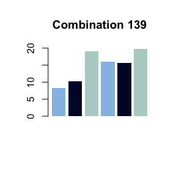

```r
barplot(BOD$demand, col = sanzo.trio("c139"), main = "Combination 139",
        ylim = c(0, 20), border = NA)
```

## Use with `ggplot2` and the `ggthemes` extension.

### Violin plot.

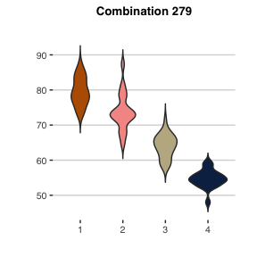

```r
ggplot(df_scatter, aes(category, x), color = as.factor(category)) +
  geom_violin(aes(fill = factor(category)), trim = FALSE) +
  theme_hc() +
  scale_fill_manual(name = "",
                     values = sanzo.quad("c279")) +
  theme(axis.text = element_text(size = 8),
        axis.title = element_text(size = 10),
        plot.title = element_text(size = 10, face = "bold", hjust = 0.5),
        legend.position = "none") +
  labs(y = "",
        x = "",
        fill = "",
        title = "Combination 279\n") +
  theme(aspect.ratio = 1)
```

### Use as gradient.

By default, `sanzo` palettes are discrete. There are multiple ways to achieve a gradient. For example, using `scale_fill_gradientn` or `scale_color_gradientn` in `ggplot2` allows you to use any `sanzo` palette as a continuous gradient.

This example uses data from the `datasets` package and should be replicable. Continuous colors via `scale_fill_gradientn` and plot theme via `theme_few` from the `ggthemes` extension.

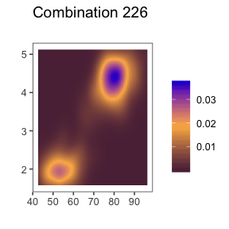

```r
ggplot(faithfuld, aes(waiting, eruptions)) +
  geom_raster(aes(fill = density), interpolate = TRUE) +
  theme_few() +
  scale_fill_gradientn(colors = sanzo.trio("c226")) +
  labs(y = "",
        x = "",
        fill = "",
        title = "Combination 226\n")
```

### Bar plot.

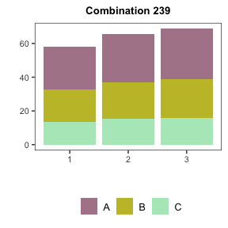

```r
ggplot(mean, aes(fill = Concentration, y = CT, x = Target)) +
  geom_bar(stat = "identity") +
  theme_few() +
  scale_fill_manual(values = sanzo.trio("c239"), labels = c("A", "B", "C")) +
  theme(axis.text = element_text(size = 8),
        axis.title = element_text(size = 10),
        plot.title = element_text(size = 10, face = "bold", hjust = 0.5),
        legend.title = element_text(size = 10),
        legend.position = "bottom",
        legend.direction = "horizontal") +
  scale_x_discrete(labels = c("1", "2", "3")) +
  labs(y = "",
        x = "",
        fill = "",
        title = "Combination 239")
```